# MP Oyster Depuration Project

Garth C

January 9, 2018

Load the libraries we’ll need. You’ll have to install these if you don’t already have them.

```r
library(plyr)
library(reshape2)
library(ggplot2)
library(glmmADMB)
library(MuMIn)
```

## Load, organize, and plot data

Import the oyster depuration data and view it.

```r
oysterdep <-
  read.csv("~/GRAD school/ACRDP/Depuration/Data/Analysis/R code/oysterdep.csv")

head(oysterdep)
```

```
##     id sampleday          size.cat Table Tank  species  DOFSample length
## 1 MIS1         0        twentyto50   n/a  n/a C. gigas 11-03-2016     93
## 2 MIS1         0        fiftyto100   n/a  n/a C. gigas 11-03-2016     93
## 3 M1S1         0   onehundredto500   n/a  n/a C. gigas 11-03-2016     93
## 4 M1S1         0 fivehundredto1000   n/a  n/a C. gigas 11-03-2016     93
## 5 M1S1         0 onethousandto5000   n/a  n/a C. gigas 11-03-2016     93
## 6 MIS2         0        twentyto50   n/a  n/a C. gigas 11-03-2016     66
##   width depth cont.weight cont.dryweight dry.weight shell.dry.weight    CI
## 1    43    21      259.28         260.96       1.68            17.65 0.095
## 2    43    21      259.28         260.96       1.68            17.65 0.095
## 3    43    21      259.28         260.96       1.68            17.65 0.095
## 4    43    21      259.28         260.96       1.68            17.65 0.095
## 5    43    21      259.28         260.96       1.68            17.65 0.095
## 6    40    21      262.04         263.63       1.59            12.62 0.126
##        time.in.oven    time.out.oven dat.filter  dat.count observer
```

[output cut: 34 more lines]

Get all of the variables into the right format.

```r
oysterdep$id <- as.factor(oysterdep$id)
oysterdep$sampleday <- as.factor(oysterdep$sampleday)
oysterdep$size.cat <- as.factor(oysterdep$size.cat)
oysterdep$Table <- as.factor(oysterdep$Table)
oysterdep$Tank <- as.factor(oysterdep$Tank)
oysterdep$observer <- as.factor(oysterdep$observer)
```

Make a new dataframe to work with and rename size categories.

```r
oysterdep2 <- oysterdep

oysterdep2$size.cat <- factor(oysterdep2$size.cat,
                              levels=c('twentyto50', 'fiftyto100',
                                       'onehundredto500', 'fivehundredto1000',
                                       'onethousandto5000'))  # reorder


oysterdep2$size.cat <- mapvalues(oysterdep2$size.cat,
                                 from = c('twentyto50', 'fiftyto100',
                                          'onehundredto500',
                                          'fivehundredto1000',
                                          'onethousandto5000'),
                                 to = c('20-50', '50-100', '100-500',
                                        '500-1000', '1000-5000'))  # rename
summary(oysterdep2$size.cat)  # view
```

```
##     20-50    50-100   100-500  500-1000 1000-5000
##        49        50        50        50        50
```

We need to melt the dataframe so that the particle types are organized by row instead of by column.

```r
oysterdep3 <- melt(oysterdep2,
                   id.vars = c('id', 'sampleday', 'size.cat', 'Table', 'Tank',
                               'species', 'DOFSample', 'length', 'width',
                               'depth', 'cont.weight', 'cont.dryweight',
                               'dry.weight', 'shell.dry.weight', 'CI',
                               'time.in.oven', 'time.out.oven',
                               'dat.filter', 'dat.count', 'observer'))

##  Take out unnecessary columns

oysterdep3 <- oysterdep3[c('id', 'sampleday', 'size.cat', 'Table', 'Tank',
                         'DOFSample', 'length', 'width', 'depth', 'dry.weight',
                         'shell.dry.weight', 'CI', 'dat.filter', 'dat.count',
                         'observer', 'variable', 'value')]

head(oysterdep3)  # now 'variable' is particle category and 'value is the count'
```

```
##     id sampleday  size.cat Table Tank  DOFSample length width depth
## 1 MIS1         0     20-50   n/a  n/a 11-03-2016     93    43    21
## 2 MIS1         0    50-100   n/a  n/a 11-03-2016     93    43    21
## 3 M1S1         0   100-500   n/a  n/a 11-03-2016     93    43    21
## 4 M1S1         0  500-1000   n/a  n/a 11-03-2016     93    43    21
## 5 M1S1         0 1000-5000   n/a  n/a 11-03-2016     93    43    21
## 6 MIS2         0     20-50   n/a  n/a 11-03-2016     66    40    21
##   dry.weight shell.dry.weight    CI dat.filter  dat.count observer
## 1       1.68            17.65 0.095 11-17-2016 11-29-2016       MD
## 2       1.68            17.65 0.095 11-17-2016 11-29-2016       MD
## 3       1.68            17.65 0.095 11-17-2016 11-29-2016       MD
## 4       1.68            17.65 0.095 11-17-2016 11-29-2016       MD
## 5       1.68            17.65 0.095 11-17-2016 11-29-2016       MD
## 6       1.59            12.62 0.126 11-17-2016 11-28-2016       GC
##   variable value
## 1  red.fib     0
## 2  red.fib     0
## 3  red.fib     0
## 4  red.fib     0
## 5  red.fib     0
## 6  red.fib     0
```

Now we want to see what kind of particles we found and remove any categories that we didn’t end up using.

```r
cat.sums <- aggregate(oysterdep3$value ~
                        oysterdep3$variable, FUN = sum)  # sums everything
print(cat.sums)
```

```
##    oysterdep3$variable oysterdep3$value
## 1              red.fib                1
## 2             yell.fib                3
## 3            green.fib                4
## 4             turq.fib                1
## 5              blu.fib               52
## 6             purp.fib                0
## 7             gray.fib                0
## 8            clear.fib              302
## 9             pink.fib                2
## 10           brown.fib                9
## 11           orang.fib                3
## 12           black.fib              158
## 13            red.frag                1
## 14           yell.frag                0
## 15          green.frag                1
## 16           turq.frag                0
## 17            blu.frag                2
## 18           purp.frag                0
## 19           gray.frag                0
## 20          clear.frag                2
## 21           pink.frag                2
## 22          brown.frag                0
## 23          orang.frag                0
## 24          black.frag                0
## 25          whit.spher                6
## 26         clear.spher                1
```

So we can remove the purple fibre, gray fibre, yellow fragment, purple fragment, gray fragment, brown fragment, orange fragment, and black fragment categories because we didn’t count any of these.

```r
oysterdep4 <- subset(oysterdep3, variable != 'purp.fib' &
                       variable != 'gray.fib' & variable != 'yell.frag' &
                       variable != 'purp.frag' & variable != 'gray.frag' &
                       variable != 'brown.frag' & variable != 'orang.frab' &
                       variable != 'black.frag')  # removes all these rows

oysterdep4$variable <- as.character(oysterdep4$variable)
oysterdep4$variable <- as.factor(oysterdep4$variable)  # gets rid of those names

summary(oysterdep4$variable)  # view
```

```
##   black.fib     blu.fib    blu.frag   brown.fib   clear.fib  clear.frag
##         249         249         249         249         249         249
## clear.spher   green.fib  green.frag   orang.fib  orang.frag    pink.fib
##         249         249         249         249         249         249
##   pink.frag     red.fib    red.frag    turq.fib   turq.frag  whit.spher
##         249         249         249         249         249         249
##    yell.fib
##         249
```

Let’s make the category names a bit more useful for plotting

```r
oysterdep4$variable <- mapvalues(oysterdep4$variable,
                                 from = c(levels(oysterdep4$variable)),
                                 to = c('Black fibres', 'Blue fibres',
                                 'Blue fragments', 'Brown fibres',
                                 'Clear fibres', 'Clear fragments',
                                 'Clear spherules', 'Green fibres',
                                 'Green fragments', 'Orange fibres',
                                 'Orange fragments', 'Pink fibres',
                                 'Pink fragments', 'Red fibres',
                                 'Red fragments', 'Turquoise fibres',
                                 'Turquoise fragments', 'White spherules',
                                 'Yellow fibres'))

## And reorder them
oysterdep4$variable <- factor(oysterdep4$variable,
                              levels = c('Black fibres', 'Blue fibres',
                                         'Brown fibres', 'Clear fibres',
                                         'Green fibres', 'Orange fibres',
                                         'Pink fibres', 'Red fibres',
                                         'Turquoise fibres',
                                         'Yellow fibres', 'Blue fragments',
                                         'Clear fragments', 'Green fragments',
                                         'Orange fragments', 'Pink fragments',
                                         'Red fragments', 'Turquoise fragments',
                                         'Clear spherules', 'White spherules'))

summary(oysterdep4$variable)
```

```
##        Black fibres         Blue fibres        Brown fibres
##                 249                 249                 249
##        Clear fibres        Green fibres       Orange fibres
##                 249                 249                 249
##         Pink fibres          Red fibres    Turquoise fibres
##                 249                 249                 249
##       Yellow fibres      Blue fragments     Clear fragments
##                 249                 249                 249
##     Green fragments    Orange fragments      Pink fragments
##                 249                 249                 249
##       Red fragments Turquoise fragments     Clear spherules
##                 249                 249                 249
##     White spherules
##                 249
```

Next let’s make plots of the distribution of sizes and particle types and colours.

Starting with size

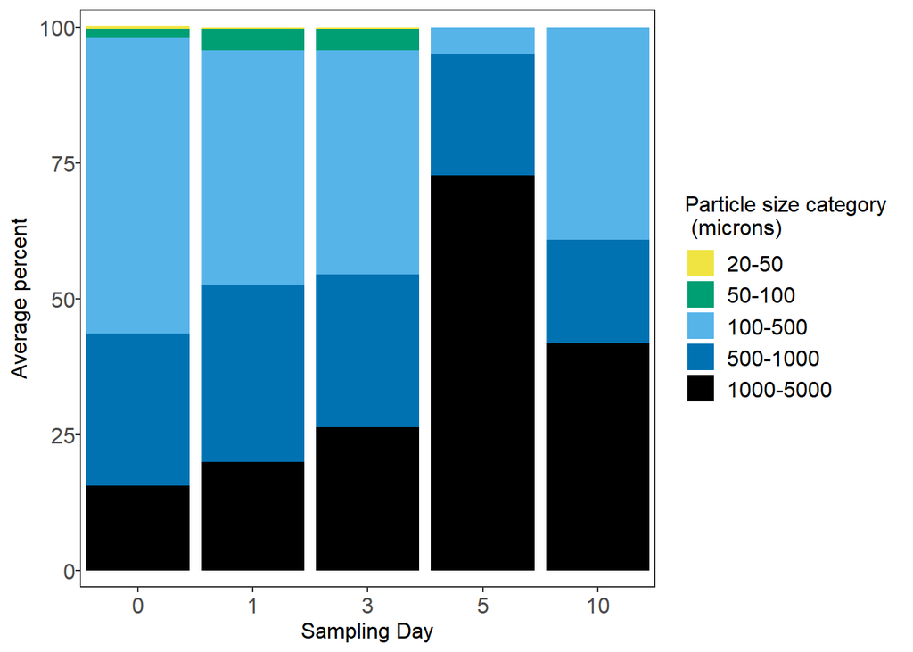

```r
## First we need to make a new data frame of sums according to each size category

oystersizesums <- ddply(oysterdep4, c('id', 'sampleday', 'size.cat', 'Table',
                                      'Tank', 'DOFSample', 'length', 'width',
                                      'depth', 'dry.weight', 'shell.dry.weight',
                                      'CI', 'dat.filter', 'dat.count',
                                      'observer'), summarize, sum = sum(value))



## Now calculate proportions of each particle size category present in each
## sample and take the means for each sampling day

oysterprop <- ddply(oystersizesums, 'id', transform, prop = sum/sum(sum))

oysterprop2 <- subset(oysterprop, !(is.na(oysterprop["prop"])))  # remove any NAs

oysterprop2$size.cat <- as.character(oysterprop2$size.cat)
oysterprop2$size.cat <- as.factor(oysterprop2$size.cat)

oysterprop3 <- ddply(oysterprop2, c("sampleday", "size.cat"), summarize,
                     mean = mean(prop))

## Put the size categories in order

oysterprop3$size.cat <- factor(oysterprop3$size.cat,
                                  levels = c("10-20", "20-50", "50-100",
                                             "100-500", "500-1000",
                                             "1000-5000"))

## Now plot

ggplot(oysterprop3, aes(x=sampleday, y=100*mean, fill = size.cat)) +
  geom_col(size = 1) +
  xlab('Sampling Day') +
  ylab('Average percent') +
  guides(fill=guide_legend(title="Particle size category \n (microns)")) +
  theme_bw() +
  scale_fill_manual(values = c("#F0E442", "#009E73",
                               "#56B4E9", "#0072B2", "black")) +
  theme(legend.text = element_text(size=12), text = element_text(size=12),
        panel.spacing = unit(1, "lines"),
        axis.text.x = element_text(size = 12),
        axis.text.y = element_text(size = 12,
                                   margin = margin(t=0, r=0, b=0, l=2)),
        strip.background = element_blank(),
        panel.grid.major = element_blank(),
        panel.grid.minor = element_blank(),
        strip.placement = "outside") +
  scale_x_discrete(expand = expand_scale(0,0.5)) +
  scale_y_continuous(expand = expand_scale(0.03,0))
```

Now with particle type/colour

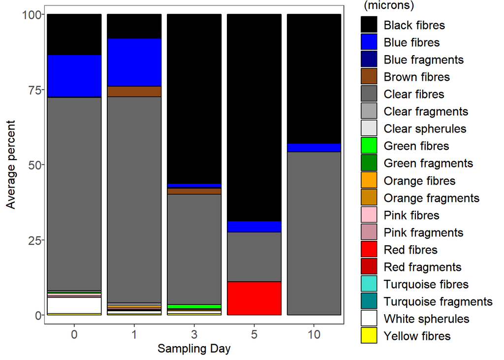

```r
## First we need to make a new data frame of sums according to each particle
## type/colour

oystertypesums <- ddply(oysterdep4, c('id', 'sampleday', 'Table',
                                      'Tank', 'DOFSample', 'length', 'width',
                                      'depth', 'dry.weight', 'shell.dry.weight',
                                      'CI', 'dat.filter', 'dat.count',
                                      'observer', 'variable'), summarize,
                        sum = sum(value))



## Now calculate proportions of each particle type/colour present in each
## sample and take the means for each sampling day

oystertypeprop <- ddply(oystertypesums, 'id', transform, prop = sum/sum(sum))

oystertypeprop2 <- subset(oystertypeprop, !(is.na(oystertypeprop["prop"])))  # remove any NAs

oystertypeprop2$variable <- as.character(oystertypeprop2$variable)
oystertypeprop2$variable <- as.factor(oystertypeprop2$variable)

oystertypeprop3 <- ddply(oystertypeprop2, c("sampleday", "variable"), summarize,
                     mean = mean(prop))

## Now plot

ggplot(oystertypeprop3, aes(x=sampleday, y=100*mean, fill = variable)) +
  geom_col(size = 0.5, colour = 'black') +
  xlab('Sampling Day') +
  ylab('Average percent') +
  guides(fill=guide_legend(title="Particle size category \n (microns)")) +
  theme_bw() +
  scale_fill_manual(values = c('black', 'blue', 'blue4', 'saddlebrown', 'grey40',
                               'grey65', 'grey90', 'green', 'green4',
                               'orange',  'orange3', 'pink', 'pink3',
                               'red', 'red3', 'turquoise', 'turquoise4',
                               'white', 'yellow')) +
  theme(legend.text = element_text(size=12), text = element_text(size=12),
        panel.spacing = unit(1, "lines"),
        axis.text.x = element_text(size = 12),
        axis.text.y = element_text(size = 12,
                                   margin = margin(t=0, r=0, b=0, l=2)),
        strip.background = element_blank(),
        panel.grid.major = element_blank(),
        panel.grid.minor = element_blank(),
        strip.placement = "outside") +
  scale_x_discrete(expand = expand_scale(0,0.5)) +
  scale_y_continuous(expand = expand_scale(0.03,0))
```

Take total sums overall and plot the results.

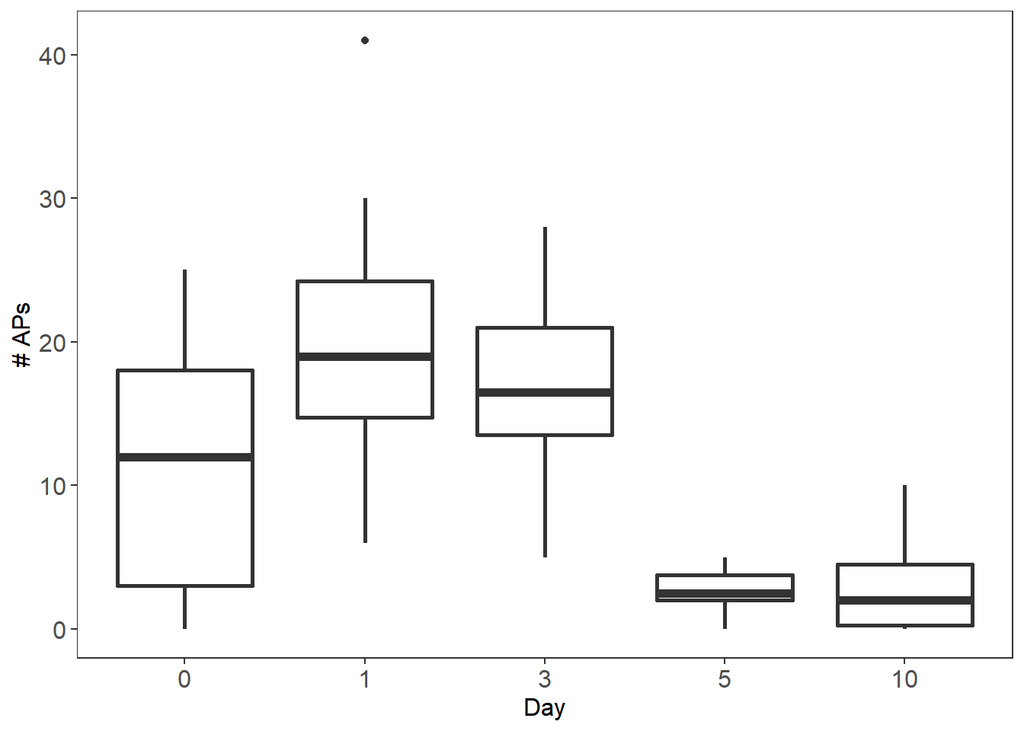

```r
totalsums <- ddply(oysterdep4, c('id', 'sampleday', 'Table', 'Tank',
                                 'length', 'width', 'depth', 'dry.weight',
                                 'shell.dry.weight', 'CI', 'observer'),
                   summarise, sum = sum(value))  # adds all the counts together

## Plot according to count per individual

ggplot(totalsums, aes(x=sampleday , y=sum)) +
  geom_boxplot(position=position_dodge(), size=1) +
  xlab('Day') +
  coord_cartesian(ylim = c(0, 41)) +
  ylab('# APs') +
  guides(fill=FALSE) +
  theme_bw() +
  theme(text = element_text(size=12),
        axis.text.x = element_text(size = 12),
        axis.text.y = element_text(size = 12),
        strip.background = element_blank(),
        panel.grid.major = element_blank(),
        panel.grid.minor = element_blank())
```

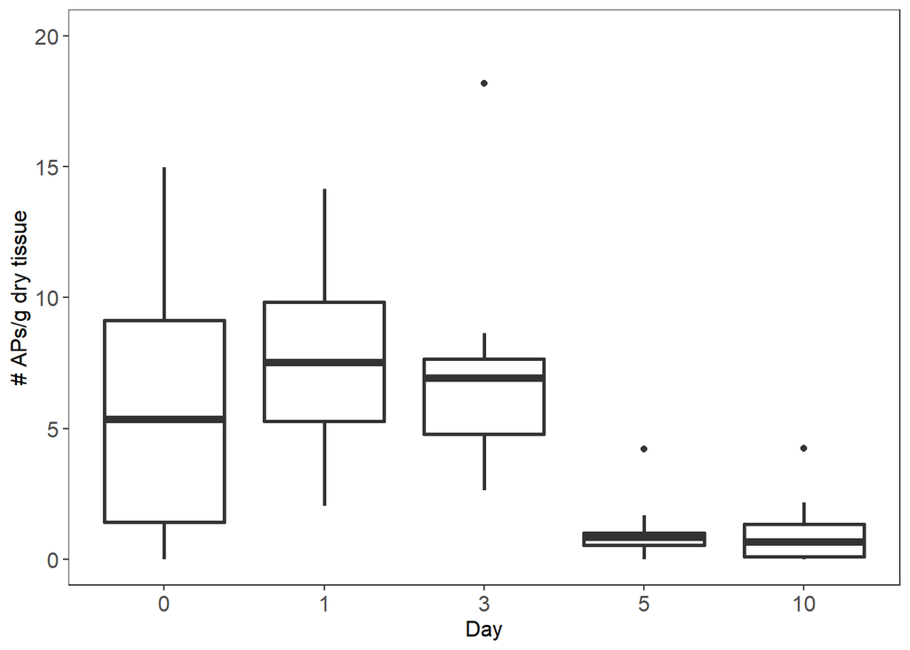

```r
## Plot according to concentration (particles/dry tissue weight)

ggplot(totalsums, aes(x=sampleday , y=sum/dry.weight)) +
  geom_boxplot(position=position_dodge(), size=1) +
  xlab('Day') +
  coord_cartesian(ylim = c(0, 20)) +
  ylab('# APs/g dry tissue') +
  guides(fill=FALSE) +
  theme_bw() +
  theme(text = element_text(size=12),
        axis.text.x = element_text(size = 12),
        axis.text.y = element_text(size = 12),
        strip.background = element_blank(),
        panel.grid.major = element_blank(),
        panel.grid.minor = element_blank())
```

Let’s print out some summary stats.

```r
## Summary stats according to count per individual

with(totalsums, tapply(sum, sampleday, mean))  # takes mean for each day
```

```
##        0        1        3        5       10
## 11.36364 20.40000 16.60000  2.60000  2.90000
```

```r
with(totalsums, tapply(sum, sampleday, min))  # takes minimum for each day
```

```
##  0  1  3  5 10
##  0  6  5  0  0
```

```r
with(totalsums, tapply(sum, sampleday, max))  # takes maximum for each day
```

```
##  0  1  3  5 10
## 25 41 28  5 10
```

```r
with(totalsums, tapply(sum,
                       sampleday, sd))  # takes standard deviation for each day
```

```
##        0        1        3        5       10
## 9.531765 9.968840 7.260242 1.505545 3.281260
```

```r
## Summary stats according to concentration

with(totalsums, tapply(sum/dry.weight,
                       sampleday, mean))  # takes mean for each day
```

```
##        0        1        3        5       10
## 5.698379 7.612293 7.261758 1.106082 1.043232
```

```r
with(totalsums, tapply(sum/dry.weight,
                       sampleday, min))  # takes minimum for each day
```

```
##        0        1        3        5       10
## 0.000000 2.027027 2.641509 0.000000 0.000000
```

```r
with(totalsums, tapply(sum/dry.weight,
                       sampleday, max))  # takes maximum for each day
```

```
##         0         1         3         5        10
## 14.970060 14.150943 18.181818  4.201681  4.237288
```

```r
with(totalsums, tapply(sum,
                       sampleday, sd))  # takes standard deviation for each day
```

```
##        0        1        3        5       10
## 9.531765 9.968840 7.260242 1.505545 3.281260
```

```r
## Proportions of particles sizes

sum(oysterdep4$value[oysterdep4$size.cat == '10-20'])/
  sum(oysterdep4$value)*100  # 0%
```

```
## [1] 0
```

```r
sum(oysterdep4$value[oysterdep4$size.cat == '20-50'])/
  sum(oysterdep4$value)*100  # 0.55 %
```

```
## [1] 0.5454545
```

```r
sum(oysterdep4$value[oysterdep4$size.cat == '50-100'])/
  sum(oysterdep4$value)*100  # 3.09 %
```

```
## [1] 3.090909
```

```r
sum(oysterdep4$value[oysterdep4$size.cat == '100-500'])/
  sum(oysterdep4$value)*100  # 41.82 %
```

```
## [1] 41.81818
```

```r
sum(oysterdep4$value[oysterdep4$size.cat == '500-1000'])/
  sum(oysterdep4$value)*100  # 28.00 %
```

```
## [1] 28
```

```r
sum(oysterdep4$value[oysterdep4$size.cat == '1000-5000'])/
  sum(oysterdep4$value)*100  # 26.55 %
```

```
## [1] 26.54545
```

```r
## Sums by particle type

summary(oysterdep4$variable)
```

```
##        Black fibres         Blue fibres        Brown fibres
##                 249                 249                 249
##        Clear fibres        Green fibres       Orange fibres
##                 249                 249                 249
##         Pink fibres          Red fibres    Turquoise fibres
##                 249                 249                 249
##       Yellow fibres      Blue fragments     Clear fragments
##                 249                 249                 249
##     Green fragments    Orange fragments      Pink fragments
##                 249                 249                 249
##       Red fragments Turquoise fragments     Clear spherules
##                 249                 249                 249
##     White spherules
##                 249
```

```r
sum(oysterdep4$value[oysterdep4$variable == 'Blue fragments' |
                  oysterdep4$variable == 'Clear fragments' |
                  oysterdep4$variable == 'Green fragments' |
                  oysterdep4$variable == 'Orange fragments' |
                  oysterdep4$variable == 'Pink fragments' |
                  oysterdep4$variable == 'Red fragments' |
                  oysterdep4$variable == 'Turquoise fragments'])/
  sum(oysterdep4$value) * 100
```

```
## [1] 1.454545
```

```r
sum(oysterdep4$value[oysterdep4$variable == 'Clear spherules' |
                  oysterdep4$variable == 'White spherules'])/
  sum(oysterdep4$value) * 100
```

```
## [1] 1.272727
```

```r
## 1.45% fragments
## 1.27% spherules
## 97.28% fibres

## This provides the percentage of total particles found accounted for by each
## colour/type of particles
oystersummarytable <- with(oysterdep4, tapply(value, variable, sum))
oystersummarytable <- oystersummarytable/sum(oysterdep4$value)*100
print(oystersummarytable)
```

```
##        Black fibres         Blue fibres        Brown fibres
##          28.7272727           9.4545455           1.6363636
##        Clear fibres        Green fibres       Orange fibres
##          54.9090909           0.7272727           0.5454545
##         Pink fibres          Red fibres    Turquoise fibres
##           0.3636364           0.1818182           0.1818182
##       Yellow fibres      Blue fragments     Clear fragments
##           0.5454545           0.3636364           0.3636364
##     Green fragments    Orange fragments      Pink fragments
##           0.1818182           0.0000000           0.3636364
##       Red fragments Turquoise fragments     Clear spherules
##           0.1818182           0.0000000           0.1818182
##     White spherules
##           1.0909091
```

### Blanks

Now load in the blanks dataset and set it up for plotting, same as with the oyster data set. First we load in the data.

```r
depblanks <-
  read.csv("~/GRAD school/ACRDP/Depuration/Data/Analysis/depblanks.csv")

head(depblanks)
```

```
##                id          size.cat  DOFSample      time.in.oven
## 1 MControl1 (0,1)        twentyto50 11-17-2016 2016-11-05/ 17:03
## 2 MControl1 (0,1)        fiftyto100 11-17-2016 2016-11-05/ 17:03
## 3 MControl1 (0,1)   onehundredto500 11-17-2016 2016-11-05/ 17:03
## 4 MControl1 (0,1) fivehundredto1000 11-17-2016 2016-11-05/ 17:03
## 5 MControl1 (0,1) onethousandto5000 11-17-2016 2016-11-05/ 17:03
## 6 MControl2 (0,1)        twentyto50 11-17-2016 2016-11-05/ 17:03
##      time.out.oven dat.filter  dat.count observer red.fib yell.fib
## 1 2016-11-10/18:00 11-17-2016 11-24-2016       GC       0        0
## 2 2016-11-10/18:00 11-17-2016 11-24-2016       GC       0        0
## 3 2016-11-10/18:00 11-17-2016 11-24-2016       GC       0        0
## 4 2016-11-10/18:00 11-17-2016 11-24-2016       GC       0        0
## 5 2016-11-10/18:00 11-17-2016 11-24-2016       GC       0        0
## 6 2016-11-10/18:00 11-17-2016 11-24-2016       GC       0        0
##   green.fib turq.fib blu.fib purp.fib gray.fib clear.fib pink.fib
```

[output cut: 27 more lines]

```r
depblanks$id <- as.factor(depblanks$id)
depblanks$size.cat <- as.factor(depblanks$size.cat)
depblanks$observer <- as.factor(depblanks$observer)
```

Now we make a new dataframe to work with and rename size categories.

```r
depblanks2 <- depblanks

depblanks2$size.cat <- factor(depblanks2$size.cat,
                              levels=c('twentyto50', 'fiftyto100',
                                       'onehundredto500', 'fivehundredto1000',
                                       'onethousandto5000'))  # reorder


depblanks2$size.cat <- mapvalues(depblanks2$size.cat,
                                 from = c('twentyto50', 'fiftyto100',
                                          'onehundredto500',
                                          'fivehundredto1000',
                                          'onethousandto5000'),
                                 to = c('20-50', '50-100', '100-500',
                                        '500-1000', '1000-5000'))  # rename
summary(depblanks2$size.cat)  # view
```

```
##     20-50    50-100   100-500  500-1000 1000-5000
##         9         9         9         9         9
```

Again, we melt the dataframe so that the particle types are organized by row instead of by column.

```r
depblanks3 <- melt(depblanks2,
                   id.vars = c('id', 'size.cat', 'DOFSample', 'time.in.oven',
                               'time.out.oven', 'dat.filter', 'dat.count',
                               'observer'))

##  Take out unnecessary columns

depblanks3 <- depblanks3[c('id', 'size.cat', 'DOFSample', 'dat.filter', 'dat.count',
                         'observer', 'variable', 'value')]

head(depblanks3)  # now 'variable' is particle category and 'value is the count'
```

```
##                id  size.cat  DOFSample dat.filter  dat.count observer
## 1 MControl1 (0,1)     20-50 11-17-2016 11-17-2016 11-24-2016       GC
## 2 MControl1 (0,1)    50-100 11-17-2016 11-17-2016 11-24-2016       GC
## 3 MControl1 (0,1)   100-500 11-17-2016 11-17-2016 11-24-2016       GC
## 4 MControl1 (0,1)  500-1000 11-17-2016 11-17-2016 11-24-2016       GC
## 5 MControl1 (0,1) 1000-5000 11-17-2016 11-17-2016 11-24-2016       GC
## 6 MControl2 (0,1)     20-50 11-17-2016 11-17-2016 11-24-2016       GC
##   variable value
## 1  red.fib     0
## 2  red.fib     0
## 3  red.fib     0
## 4  red.fib     0
## 5  red.fib     0
## 6  red.fib     0
```

Now sum by totals across all samples and particles sizes to get an idea of what we’re working with.

```r
cat.sums.blanks <- aggregate(depblanks3$value ~
                               depblanks3$variable, FUN = sum)  # sums everything
print(cat.sums.blanks)
```

```
##    depblanks3$variable depblanks3$value
## 1              red.fib                0
## 2             yell.fib                0
## 3            green.fib                0
## 4             turq.fib                0
## 5              blu.fib                3
## 6             purp.fib                0
## 7             gray.fib                0
## 8            clear.fib               33
## 9             pink.fib                1
## 10           brown.fib                0
## 11           orang.fib                0
## 12           black.fib                0
## 13             tot.fib               37
## 14            red.frag                0
## 15           yell.frag                0
## 16          green.frag                0
## 17           turq.frag                0
## 18            blu.frag                1
## 19           purp.frag                0
## 20           gray.frag                0
## 21          clear.frag                0
## 22           pink.frag                0
## 23          brown.frag                0
## 24          orang.frag                0
## 25          black.frag                0
## 26          whit.spher                0
## 27         clear.spher                0
## 28      tot.frag.spher                1
## 29            tot.part                1
```

So we can remove the red, yellow, green turquoise, purple, gray, brown, orange, and black fibre categories, and all other categories other than blue fragements.

```r
depblanks4 <- subset(depblanks3, c(variable == 'blu.fib' |
                       variable == 'clear.fib' | variable == 'pink.fib' |
                       variable == 'blu.frag'))  # keep only these rows

depblanks4$variable <- as.character(depblanks4$variable)
depblanks4$variable <- as.factor(depblanks4$variable)  # gets rid of those names

summary(depblanks4$variable)  # view
```

```
##   blu.fib  blu.frag clear.fib  pink.fib
##        45        45        45        45
```

Let’s make the category names a bit more useful for plotting

```r
depblanks4$variable <- mapvalues(depblanks4$variable,
                                 from = c(levels(depblanks4$variable)),
                                 to = c('Blue fibres', 'Blue fragments',
                                        'Clear fibres', 'Pink fibres'))

## And reorder them
depblanks4$variable <- factor(depblanks4$variable,
                              levels = c('Blue fibres', 'Clear fibres',
                                         'Pink fibres', 'Blue fragments'))

summary(depblanks4$variable)
```

```
##    Blue fibres   Clear fibres    Pink fibres Blue fragments
##             45             45             45             45
```

Next let’s make plots of the distribution of sizes and particle types and colours.

Starting with size

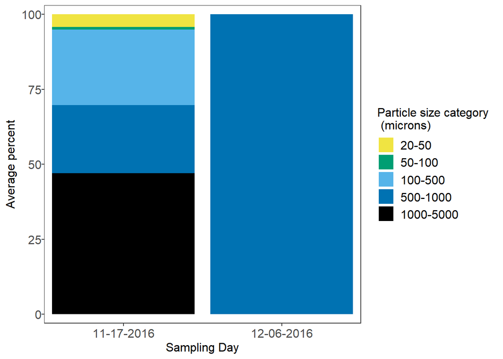

```r
## First we need to make a new data frame of sums according to each size category

blankssizesums <- ddply(depblanks4, c('id', 'size.cat', 'DOFSample',
                                      'dat.filter', 'dat.count',
                                      'observer'), summarize, sum = sum(value))



## Now calculate proportions of each particle size category present in each
## sample and take the means for each sampling day

blanksprop <- ddply(blankssizesums, 'id', transform, prop = sum/sum(sum))

blanksprop2 <- subset(blanksprop, !(is.na(blanksprop["prop"])))  # remove any NAs

blanksprop2$size.cat <- as.character(blanksprop2$size.cat)
blanksprop2$size.cat <- as.factor(blanksprop2$size.cat)

blanksprop3 <- ddply(blanksprop2, c("DOFSample", "size.cat"), summarize,
                     mean = mean(prop))

## Put the size categories in order

blanksprop3$size.cat <- factor(blanksprop3$size.cat,
                                  levels = c("10-20", "20-50", "50-100",
                                             "100-500", "500-1000",
                                             "1000-5000"))

## Now plot

ggplot(blanksprop3, aes(x=DOFSample, y=100*mean, fill = size.cat)) +
  geom_col(size = 1) +
  xlab('Sampling Day') +
  ylab('Average percent') +
  guides(fill=guide_legend(title="Particle size category \n (microns)")) +
  theme_bw() +
  scale_fill_manual(values = c("#F0E442", "#009E73",
                               "#56B4E9", "#0072B2", "black")) +
  theme(legend.text = element_text(size=12), text = element_text(size=12),
        panel.spacing = unit(1, "lines"),
        axis.text.x = element_text(size = 12),
        axis.text.y = element_text(size = 12,
                                   margin = margin(t=0, r=0, b=0, l=2)),
        strip.background = element_blank(),
        panel.grid.major = element_blank(),
        panel.grid.minor = element_blank(),
        strip.placement = "outside") +
  scale_x_discrete(expand = expand_scale(0,0.5)) +
  scale_y_continuous(expand = expand_scale(0.03,0))
```

Now with particle type/colour

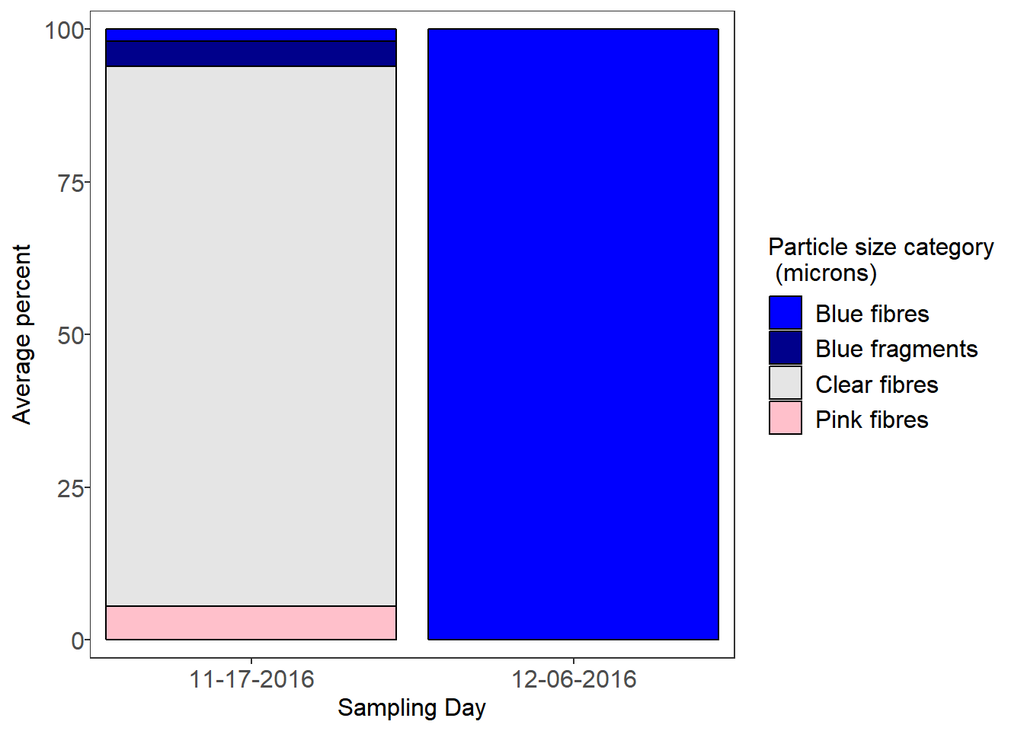

```r
## First we need to make a new data frame of sums according to each particle
## type/colour

blankstypesums <- ddply(depblanks4, c('id', 'DOFSample', 'dat.filter',
                                      'dat.count', 'observer', 'variable'),
                        summarize, sum = sum(value))



## Now calculate proportions of each particle type/colour present in each
## sample and take the means for each sampling day

blankstypeprop <- ddply(blankstypesums, 'id', transform, prop = sum/sum(sum))

blankstypeprop2 <- subset(blankstypeprop, !(is.na(blankstypeprop["prop"])))  # remove any NAs

blankstypeprop2$variable <- as.character(blankstypeprop2$variable)
blankstypeprop2$variable <- as.factor(blankstypeprop2$variable)

blankstypeprop3 <- ddply(blankstypeprop2, c("DOFSample", "variable"), summarize,
                     mean = mean(prop))

## Now plot

ggplot(blankstypeprop3, aes(x=DOFSample, y=100*mean, fill = variable)) +
  geom_col(size = 0.5, colour = 'black') +
  xlab('Sampling Day') +
  ylab('Average percent') +
  guides(fill=guide_legend(title="Particle size category \n (microns)")) +
  theme_bw() +
  scale_fill_manual(values = c('blue', 'blue4', 'grey90', 'pink')) +
  theme(legend.text = element_text(size=12), text = element_text(size=12),
        panel.spacing = unit(1, "lines"),
        axis.text.x = element_text(size = 12),
        axis.text.y = element_text(size = 12,
                                   margin = margin(t=0, r=0, b=0, l=2)),
        strip.background = element_blank(),
        panel.grid.major = element_blank(),
        panel.grid.minor = element_blank(),
        strip.placement = "outside") +
  scale_x_discrete(expand = expand_scale(0,0.5)) +
  scale_y_continuous(expand = expand_scale(0.03,0))
```

Take total sums and plot the results.

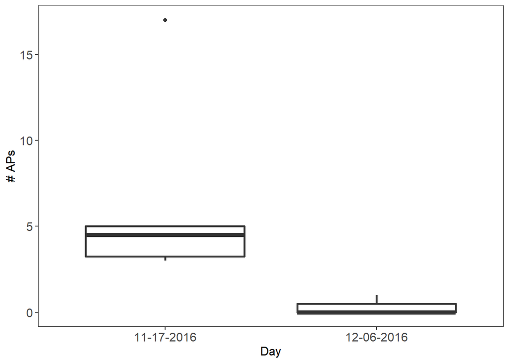

```r
totalblanksums <- ddply(depblanks4, c('id', 'observer', 'dat.filter', 'DOFSample'),
                   summarise, sum = sum(value))  # adds all the counts together

## Plot according to count per filtration day

ggplot(totalblanksums, aes(x=DOFSample, y=sum)) +
  geom_boxplot(position=position_dodge(), size=1) +
  xlab('Day') +
  ylab('# APs') +
  guides(fill=FALSE) +
  theme_bw() +
  theme(text = element_text(size=12),
        axis.text.x = element_text(size = 12),
        axis.text.y = element_text(size = 12),
        strip.background = element_blank(),
        panel.grid.major = element_blank(),
        panel.grid.minor = element_blank())
```

Now do the same summary stats for the blanks

```r
## Means, range, and SD

with(totalblanksums, tapply(sum, DOFSample, mean))  # takes mean for each day
```

```
## 11-17-2016 12-06-2016
##  6.1666667  0.3333333
```

```r
with(totalblanksums, tapply(sum, DOFSample, min))  # takes minimum for each day
```

```
## 11-17-2016 12-06-2016
##          3          0
```

```r
with(totalblanksums, tapply(sum, DOFSample, max))  # takes maximum for each day
```

```
## 11-17-2016 12-06-2016
##         17          1
```

```r
with(totalblanksums, tapply(sum,
                       DOFSample, sd))  # takes standard deviation for each day
```

```
## 11-17-2016 12-06-2016
##  5.3820690  0.5773503
```

```r
## Proportions of particles sizes

sum(depblanks4$value[depblanks4$size.cat == '10-20'])/
  sum(depblanks4$value)*100  # 0%
```

```
## [1] 0
```

```r
sum(depblanks4$value[depblanks4$size.cat == '20-50'])/
  sum(depblanks4$value)*100  # 2.63 %
```

```
## [1] 2.631579
```

```r
sum(depblanks4$value[depblanks4$size.cat == '50-100'])/
  sum(depblanks4$value)*100  # 2.63 %
```

```
## [1] 2.631579
```

```r
sum(depblanks4$value[depblanks4$size.cat == '100-500'])/
  sum(depblanks4$value)*100  # 42.11 %
```

```
## [1] 42.10526
```

```r
sum(depblanks4$value[depblanks4$size.cat == '500-1000'])/
  sum(depblanks4$value)*100  # 23.68 %
```

```
## [1] 23.68421
```

```r
sum(depblanks4$value[depblanks4$size.cat == '1000-5000'])/
  sum(depblanks4$value)*100  # 28.95 %
```

```
## [1] 28.94737
```

```r
## This provides the percentage of total particles found accounted for by each
## colour/type of particles
blanksummarytable <- with(depblanks4, tapply(value, variable, sum))
blanksummarytable <- blanksummarytable/sum(depblanks4$value)*100
print(blanksummarytable)
```

```
##    Blue fibres   Clear fibres    Pink fibres Blue fragments
##       7.894737      86.842105       2.631579       2.631579
```

Now load in the water sample data.

```r
depwater <-
  read.csv("~/GRAD school/ACRDP/Depuration/Data/Analysis/depwater.csv")

head(depwater)
```

```
##                        id     day          size.cat   Table Tank
## 1 Water Control Control 1 Control        twentyto50 Control  n/a
## 2 Water Control Control 1 Control        fiftyto100 Control  n/a
## 3 Water Control Control 1 Control   onehundredto500 Control  n/a
## 4 Water Control Control 1 Control fivehundredto1000 Control  n/a
## 5 Water Control Control 1 Control onethousandto5000 Control  n/a
## 6 Water Control Control 2 Control        twentyto50 Control  n/a
##    DOFSample     time.in.oven    time.out.oven dat.filter  dat.count
## 1 12-13-2017 2017-01-09/17:00 2017-01-17/09:30 12-13-2017 12-20-2017
## 2 12-13-2017 2017-01-09/17:00 2017-01-17/09:30 12-13-2017 12-20-2017
## 3 12-13-2017 2017-01-09/17:00 2017-01-17/09:30 12-13-2017 12-20-2017
## 4 12-13-2017 2017-01-09/17:00 2017-01-17/09:30 12-13-2017 12-20-2017
## 5 12-13-2017 2017-01-09/17:00 2017-01-17/09:30 12-13-2017 12-20-2017
## 6 12-13-2017 2017-01-09/17:00 2017-01-17/09:30 12-13-2017 12-20-2017
##   observer red.fib yell.fib green.fib turq.fib blu.fib purp.fib gray.fib
```

[output cut: 34 more lines]

```r
depwater$id <- as.factor(depwater$id)
depwater$day <- as.factor(depwater$day)
depwater$size.cat <- as.factor(depwater$size.cat)
depwater$Table <- as.factor(depwater$Table)
depwater$Tank <- as.factor(depwater$Tank)
depwater$observer <- as.factor(depwater$observer)
```

Now we make a new dataframe to work with and rename size categories.

```r
depwater2 <- depwater

depwater2$size.cat <- factor(depwater2$size.cat,
                              levels=c('twentyto50', 'fiftyto100',
                                       'onehundredto500', 'fivehundredto1000',
                                       'onethousandto5000'))  # reorder


depwater2$size.cat <- mapvalues(depwater2$size.cat,
                                 from = c('twentyto50', 'fiftyto100',
                                          'onehundredto500',
                                          'fivehundredto1000',
                                          'onethousandto5000'),
                                 to = c('20-50', '50-100', '100-500',
                                        '500-1000', '1000-5000'))  # rename
summary(depwater2$size.cat)  # view
```

```
##     20-50    50-100   100-500  500-1000 1000-5000
##        23        23        23        23        23
```

Again, we melt the dataframe so that the particle types are organized by row instead of by column.

```r
depwater3 <- melt(depwater2,
                   id.vars = c('id', 'day', 'size.cat', 'Table', 'Tank',
                               'DOFSample', 'time.in.oven', 'time.out.oven',
                               'dat.filter',  'dat.count', 'observer'))

##  Take out unnecessary columns

depwater3 <- depwater3[c('id', 'day', 'size.cat', 'Table', 'Tank', 'DOFSample',
                         'dat.filter', 'dat.count', 'observer', 'variable',
                         'value')]

head(depwater3)  # now 'variable' is particle category and 'value is the count'
```

```
##                        id     day  size.cat   Table Tank  DOFSample
## 1 Water Control Control 1 Control     20-50 Control  n/a 12-13-2017
## 2 Water Control Control 1 Control    50-100 Control  n/a 12-13-2017
## 3 Water Control Control 1 Control   100-500 Control  n/a 12-13-2017
## 4 Water Control Control 1 Control  500-1000 Control  n/a 12-13-2017
## 5 Water Control Control 1 Control 1000-5000 Control  n/a 12-13-2017
## 6 Water Control Control 2 Control     20-50 Control  n/a 12-13-2017
##   dat.filter  dat.count observer variable value
## 1 12-13-2017 12-20-2017       MD  red.fib     0
## 2 12-13-2017 12-20-2017       MD  red.fib     0
## 3 12-13-2017 12-20-2017       MD  red.fib     0
## 4 12-13-2017 12-20-2017       MD  red.fib     0
## 5 12-13-2017 12-20-2017       MD  red.fib     0
## 6 12-13-2017 12-20-2017       MD  red.fib     0
```

Now sum by totals across all samples and particles sizes to get an idea of what we’re working with.

```r
cat.sums.blanks <- aggregate(depwater3$value ~
                               depwater3$variable, FUN = sum)  # sums everything
print(cat.sums.blanks)
```

```
##    depwater3$variable depwater3$value
## 1             red.fib               3
## 2            yell.fib               0
## 3           green.fib               0
## 4            turq.fib               1
## 5             blu.fib               7
## 6            purp.fib               0
## 7            gray.fib               0
## 8           clear.fib              37
## 9            pink.fib               0
## 10          brown.fib               0
## 11          orang.fib               0
## 12          black.fib               0
## 13            tot.fib              48
## 14           red.frag               0
## 15          yell.frag               0
## 16         green.frag               0
## 17          turq.frag               0
## 18           blu.frag               0
## 19          purp.frag               0
## 20          gray.frag               0
## 21         clear.frag               0
## 22          pink.frag               0
## 23         brown.frag               0
## 24         orang.frag               0
## 25         black.frag               0
## 26         whit.spher               0
## 27        clear.spher               0
## 28     tot.frag.spher               0
## 29           tot.part               0
```

So we can remove the yellow, green, purple, gray, pink, brown, orange, and black fibre categories, and all other categories as well.

```r
depwater4 <- subset(depwater3, c(variable == 'red.fib' |
                       variable == 'turq.fib' | variable == 'blu.fib' |
                       variable == 'clear.fib'))  # keep only these rows

depwater4$variable <- as.character(depwater4$variable)
depwater4$variable <- as.factor(depwater4$variable)  # gets rid of those names

summary(depwater4$variable)  # view
```

```
##   blu.fib clear.fib   red.fib  turq.fib
##       115       115       115       115
```

Let’s make the category names a bit more useful for plotting

```r
depwater4$variable <- mapvalues(depwater4$variable,
                                 from = c(levels(depwater4$variable)),
                                 to = c('Blue fibres', 'Clear fibres',
                                        'Red fibres', 'Turquoise fibres'))

## And reorder them
depwater4$variable <- factor(depwater4$variable,
                              levels = c('Blue fibres', 'Clear fibres',
                                         'Red fibres', 'Turquoise fibres'))

summary(depwater4$variable)
```

```
##      Blue fibres     Clear fibres       Red fibres Turquoise fibres
##              115              115              115              115
```

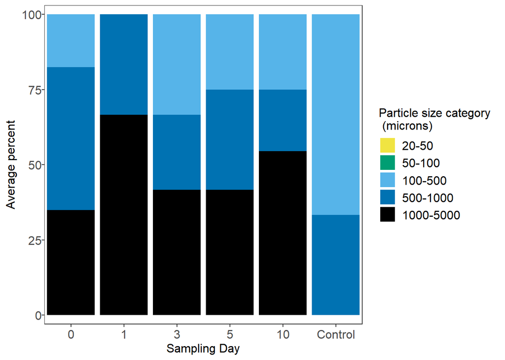

```r
## First we need to make a new data frame of sums according to each size category

depwater4$day <- factor(depwater4$day,
                        levels =
                          c('0', '1', '3', '5', '10', 'Control'))  # put in order

watersizesums <- ddply(depwater4, c('id', 'day', 'size.cat', 'Table', 'Tank',
                                    'DOFSample', 'dat.filter', 'dat.count',
                                      'observer'), summarize, sum = sum(value))



## Now calculate proportions of each particle size category present in each
## sample and take the means for each sampling day

waterprop <- ddply(watersizesums, 'id', transform, prop = sum/sum(sum))

waterprop2 <- subset(waterprop, !(is.na(waterprop["prop"])))  # remove any NAs

waterprop2$size.cat <- as.character(waterprop2$size.cat)
waterprop2$size.cat <- as.factor(waterprop2$size.cat)

waterprop3 <- ddply(waterprop2, c("day", "size.cat"), summarize,
                     mean = mean(prop))

## Put the size categories in order

waterprop3$size.cat <- factor(waterprop3$size.cat,
                                  levels = c("10-20", "20-50", "50-100",
                                             "100-500", "500-1000",
                                             "1000-5000"))

## Now plot

ggplot(waterprop3, aes(x=day, y=100*mean, fill = size.cat)) +
  geom_col(size = 1) +
  xlab('Sampling Day') +
  ylab('Average percent') +
  guides(fill=guide_legend(title="Particle size category \n (microns)")) +
  theme_bw() +
  scale_fill_manual(values = c("#F0E442", "#009E73",
                               "#56B4E9", "#0072B2", "black")) +
  theme(legend.text = element_text(size=12), text = element_text(size=12),
        panel.spacing = unit(1, "lines"),
        axis.text.x = element_text(size = 12),
        axis.text.y = element_text(size = 12,
                                   margin = margin(t=0, r=0, b=0, l=2)),
        strip.background = element_blank(),
        panel.grid.major = element_blank(),
        panel.grid.minor = element_blank(),
        strip.placement = "outside") +
  scale_x_discrete(expand = expand_scale(0,0.5)) +
  scale_y_continuous(expand = expand_scale(0.03,0))
```

Now with particle type/colour

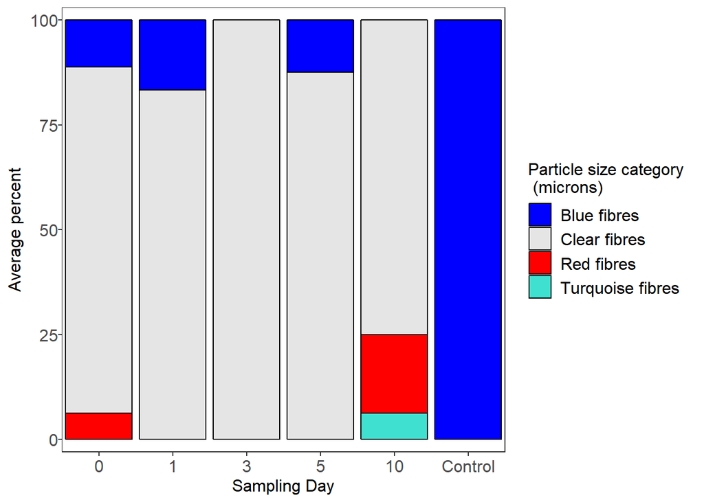

```r
## First we need to make a new data frame of sums according to each particle
## type/colour

watertypesums <- ddply(depwater4, c('id', 'day', 'Table', 'Tank',
                                    'DOFSample', 'dat.filter', 'dat.count',
                                    'observer', 'variable'),
                        summarize, sum = sum(value))



## Now calculate proportions of each particle type/colour present in each
## sample and take the means for each sampling day

watertypeprop <- ddply(watertypesums, 'id', transform, prop = sum/sum(sum))

watertypeprop2 <- subset(watertypeprop, !(is.na(watertypeprop["prop"])))  # remove any NAs

watertypeprop2$variable <- as.character(watertypeprop2$variable)
watertypeprop2$variable <- as.factor(watertypeprop2$variable)

watertypeprop3 <- ddply(watertypeprop2, c("day", "variable"), summarize,
                     mean = mean(prop))

## Now plot

ggplot(watertypeprop3, aes(x=day, y=100*mean, fill = variable)) +
  geom_col(size = 0.5, colour = 'black') +
  xlab('Sampling Day') +
  ylab('Average percent') +
  guides(fill=guide_legend(title="Particle size category \n (microns)")) +
  theme_bw() +
  scale_fill_manual(values = c('blue', 'grey90', 'red', 'turquoise')) +
  theme(legend.text = element_text(size=12), text = element_text(size=12),
        panel.spacing = unit(1, "lines"),
        axis.text.x = element_text(size = 12),
        axis.text.y = element_text(size = 12,
                                   margin = margin(t=0, r=0, b=0, l=2)),
        strip.background = element_blank(),
        panel.grid.major = element_blank(),
        panel.grid.minor = element_blank(),
        strip.placement = "outside") +
  scale_x_discrete(expand = expand_scale(0,0.5)) +
  scale_y_continuous(expand = expand_scale(0.03,0))
```

Take total sums and plot the results.

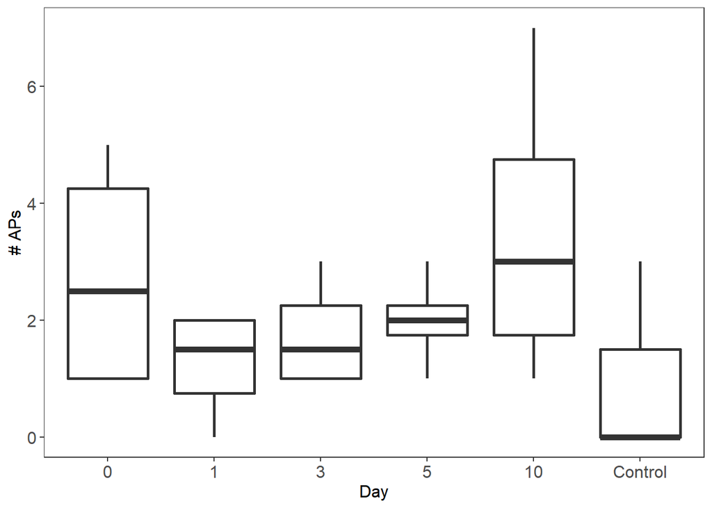

```r
totalwatersums <- ddply(depwater4, c('id', 'day', 'Table', 'Tank', 'observer',
                                     'dat.filter'),
                   summarise, sum = sum(value))  # adds all the counts together

## Plot according to count per filtration day

ggplot(totalwatersums, aes(x=day, y=sum)) +
  geom_boxplot(position=position_dodge(), size=1) +
  xlab('Day') +
  ylab('# APs') +
  guides(fill=FALSE) +
  theme_bw() +
  theme(text = element_text(size=12),
        axis.text.x = element_text(size = 12),
        axis.text.y = element_text(size = 12),
        strip.background = element_blank(),
        panel.grid.major = element_blank(),
        panel.grid.minor = element_blank())
```

Now run the same summary stats for the water samples.

```r
## Means, range, and SD

with(totalwatersums, tapply(sum, day, mean))  # takes mean for each day
```

```
##       0       1       3       5      10 Control
##    2.75    1.25    1.75    2.00    3.50    1.00
```

```r
with(totalwatersums, tapply(sum, day, min))  # takes minimum for each day
```

```
##       0       1       3       5      10 Control
##       1       0       1       1       1       0
```

```r
with(totalwatersums, tapply(sum, day, max))  # takes maximum for each day
```

```
##       0       1       3       5      10 Control
##       5       2       3       3       7       3
```

```r
with(totalwatersums, tapply(sum,
                       day, sd))  # takes standard deviation for each day
```

```
##         0         1         3         5        10   Control
## 2.0615528 0.9574271 0.9574271 0.8164966 2.6457513 1.7320508
```

```r
## Proportions of particles sizes

sum(depwater4$value[depwater4$size.cat == '10-20'])/
  sum(depwater4$value)*100  # 0%
```

```
## [1] 0
```

```r
sum(depwater4$value[depwater4$size.cat == '20-50'])/
  sum(depwater4$value)*100  # 0 %
```

```
## [1] 0
```

```r
sum(depwater4$value[depwater4$size.cat == '50-100'])/
  sum(depwater4$value)*100  # 0 %
```

```
## [1] 0
```

```r
sum(depwater4$value[depwater4$size.cat == '100-500'])/
  sum(depwater4$value)*100  # 20.83 %
```

```
## [1] 20.83333
```

```r
sum(depwater4$value[depwater4$size.cat == '500-1000'])/
  sum(depwater4$value)*100  # 31.25 %
```

```
## [1] 31.25
```

```r
sum(depwater4$value[depwater4$size.cat == '1000-5000'])/
  sum(depwater4$value)*100  # 47.92 %
```

```
## [1] 47.91667
```

```r
## This provides the percentage of total particles found accounted for by each
## colour/type of particles
watersummarytable <- with(depwater4, tapply(value, variable, sum))
watersummarytable <- watersummarytable/sum(depwater4$value)*100
print(watersummarytable)
```

```
##      Blue fibres     Clear fibres       Red fibres Turquoise fibres
##        14.583333        77.083333         6.250000         2.083333
```

## MODELLING

Now fit a generalized linear mixed model (GLMM) to the oyster data using the package glmmADMB to determine differences over time. We’ll specify AP count as the response variable, sampling day as the predictor, and tank nested within table as the random, or mixed, effects. You’ll notice that sample day is specified twice. The second time is to set it up as the intercept for the random effect, which will allow the linear relationship between AP sum and sampling day to vary in both slope and intercept according separately within each tank, within each table. This accounts for any the variation that may have been caused by any variables that we did not account for and may have varied somehow in different tanks and or/tables.

```r
M1 <- glmmadmb(sum ~ sampleday + (sampleday | Table/Tank), family = 'poisson',
               data = totalsums) ## Fits a GLMM

summary(M1) # model output
```

```
##
## Call:
## glmmadmb(formula = sum ~ sampleday + (sampleday | Table/Tank),
##     data = totalsums, family = "poisson")
##
## AIC: 384.2
##
## Coefficients:
##             Estimate Std. Error z value Pr(>|z|)
## (Intercept)   2.4304     0.0895   27.16  < 2e-16 ***
## sampleday1    0.5013     0.1764    2.84   0.0045 **
## sampleday3    0.3146     0.1696    1.86   0.0636 .
## sampleday5   -1.4749     0.2156   -6.84  7.8e-12 ***
## sampleday10  -1.6250     0.5986   -2.71   0.0066 **
## ---
## Signif. codes:  0 '***' 0.001 '**' 0.01 '*' 0.05 '.' 0.1 ' ' 1
##
## Number of observations: total=51, Table=5, Table:Tank=11
## Random effect variance(s):
```

```
## Group=Table
##              Variance    StdDev
## (Intercept) 1.127e-07 0.0003356
## sampleday1  3.806e-06 0.0019509
## sampleday3  2.116e-05 0.0045997
## sampleday5  1.355e-06 0.0011641
## sampleday10 8.624e-01 0.9286334
## Group=Table:Tank
##              Variance   StdDev
## (Intercept) 7.395e-06 0.002719
## sampleday1  1.717e-01 0.414355
## sampleday3  1.356e-01 0.368171
## sampleday5  2.560e-05 0.005060
## sampleday10 2.814e-01 0.530471
##
##
## Log-likelihood: -177.092
```

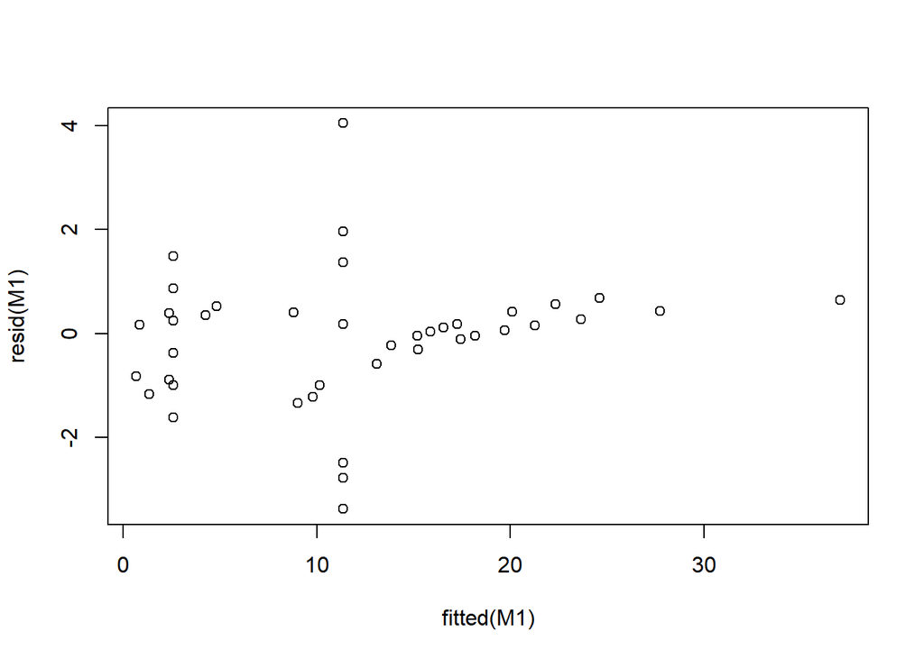

```r
plot(resid(M1) ~ fitted(M1)) # plot residuals vs. fitted
```

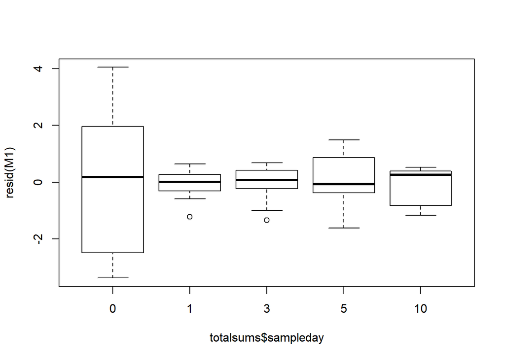

```r
plot(resid(M1) ~ totalsums$sampleday) # plot residuals vs. predictor
```

Looking at the plot of residuals vs. fitted and residuals vs. sampe day, we can see that the variance of the residuals varies according to the AP count and the sampling day. This violates the assumption of homogeneity of variance.

Let’s try fitting the same model structure, but assuming that the response variable (AP count) varies at each value of x (sampling day) according to a negative binomial distribution.

```r
M2 <- glmmadmb(sum ~ sampleday + (sampleday | Table/Tank), family = 'nbinom',
               data = totalsums) ## Fits a NB GLMM

summary(M2) # model output
```

```
##
## Call:
## glmmadmb(formula = sum ~ sampleday + (sampleday | Table/Tank),
##     data = totalsums, family = "nbinom")
##
## AIC: 338.4
##
## Coefficients:
##             Estimate Std. Error z value Pr(>|z|)
## (Intercept)    2.430      0.192   12.65  < 2e-16 ***
## sampleday1     0.585      0.271    2.16    0.031 *
## sampleday3     0.379      0.274    1.39    0.166
## sampleday5    -1.475      0.327   -4.51  6.6e-06 ***
## sampleday10   -1.485      0.576   -2.58    0.010 **
## ---
## Signif. codes:  0 '***' 0.001 '**' 0.01 '*' 0.05 '.' 0.1 ' ' 1
##
## Number of observations: total=51, Table=5, Table:Tank=11
## Random effect variance(s):
```

```
## Group=Table
##              Variance    StdDev
## (Intercept) 1.137e-07 0.0003372
## sampleday1  1.399e-06 0.0011827
## sampleday3  2.064e-04 0.0143656
## sampleday5  5.603e-06 0.0023670
## sampleday10 8.160e-01 0.9033438
## Group=Table:Tank
##              Variance    StdDev
## (Intercept) 2.438e-05 0.0049374
## sampleday1  3.457e-07 0.0005879
## sampleday3  5.310e-07 0.0007287
## sampleday5  1.819e-05 0.0042649
## sampleday10 3.480e-04 0.0186561
##
## Negative binomial dispersion parameter: 3.1455 (std. err.: 0.9495)
##
## Log-likelihood: -153.196
```

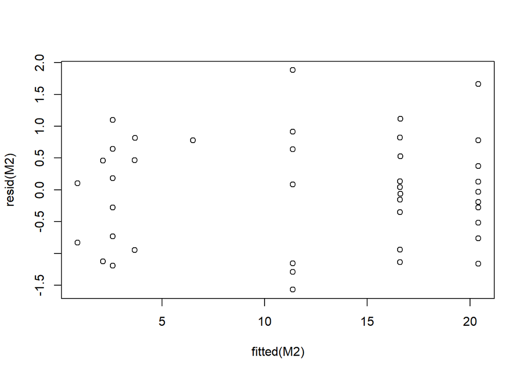

```r
plot(resid(M2) ~ fitted(M2)) # plot residuals vs. fitted
```

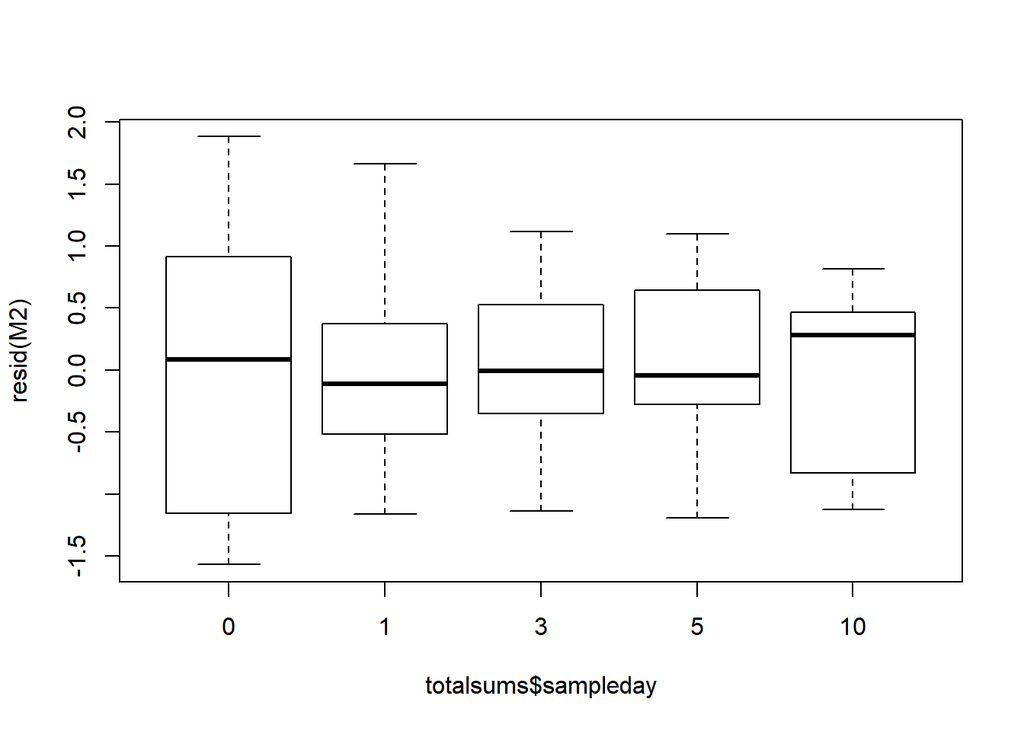

```r
plot(resid(M2) ~ totalsums$sampleday) # plot residuals vs. predictor
```

This model is a much better fit, and the variance is much more evenly distributed across the model predictions and across the predictor variable (sampling day).

Now let’s try pulling out the predictor (sampling day) and using the anova() function to compare the first model with the null models to determine whether sampling day significantly predicts AP concentration.

```r
M3 <- glmmadmb(sum ~ (sampleday | Table/Tank), family = 'nbinom',
               data = totalsums) ## Same structure except no predictor

anova(M2, M3) # compare the null model with the previously fitted model
```

```
## Analysis of Deviance Table
##
## Model 1: sum ~ 1
## Model 2: sum ~ sampleday
##   NoPar  LogLik Df Deviance  Pr(>Chi)
## 1    12 -164.23
## 2    16 -153.20  4   22.076 0.0001936 ***
## ---
## Signif. codes:  0 '***' 0.001 '**' 0.01 '*' 0.05 '.' 0.1 ' ' 1
```

Sampling day is significant with a p-value of <0.001. We can now go into the model to determine which days are significantly different from each other. Looking back at the summar of M2 we can see that day 3 is the only time where the AP concentrations are not significantly different from day 0 (the reference level).

Now we reorder the levels in sampleday to vary the reference level and figure out which days are significantly different from which other days.

```r
totalsums$sampleday <- relevel(totalsums$sampleday, '1')
M2 <- glmmadmb(sum ~ sampleday + (sampleday | Table/Tank), family = 'nbinom',
               data = totalsums) ## Fits a NB GLMM

summary(M2) # model output
```

```
##
## Call:
## glmmadmb(formula = sum ~ sampleday + (sampleday | Table/Tank),
##     data = totalsums, family = "nbinom")
##
## AIC: 338.4
##
## Coefficients:
##             Estimate Std. Error z value Pr(>|z|)
## (Intercept)    3.016      0.192   15.74  < 2e-16 ***
## sampleday0    -0.585      0.271   -2.16  0.03103 *
## sampleday3    -0.206      0.273   -0.76  0.45018
## sampleday5    -2.060      0.327   -6.30    3e-10 ***
## sampleday10   -2.070      0.575   -3.60  0.00032 ***
## ---
## Signif. codes:  0 '***' 0.001 '**' 0.01 '*' 0.05 '.' 0.1 ' ' 1
##
## Number of observations: total=51, Table=5, Table:Tank=11
## Random effect variance(s):
```

```
## Group=Table
##              Variance    StdDev
## (Intercept) 2.392e-07 0.0004891
## sampleday0  3.162e-06 0.0017783
## sampleday3  2.309e-06 0.0015195
## sampleday5  3.129e-06 0.0017688
## sampleday10 8.131e-01 0.9017261
## Group=Table:Tank
##              Variance    StdDev
## (Intercept) 1.126e-07 0.0003355
## sampleday0  3.162e-06 0.0017783
## sampleday3  7.570e-06 0.0027514
## sampleday5  2.792e-05 0.0052836
## sampleday10 8.908e-06 0.0029847
##
## Negative binomial dispersion parameter: 3.1452 (std. err.: 0.94931)
##
## Log-likelihood: -153.194
```

Similarly, day 3 is the only day not significantly different from day 1.

```r
totalsums$sampleday <- relevel(totalsums$sampleday, '3')
M2 <- glmmadmb(sum ~ sampleday + (sampleday | Table/Tank), family = 'nbinom',
               data = totalsums) ## Fits a NB GLMM

summary(M2) # model output
```

```
##
## Call:
## glmmadmb(formula = sum ~ sampleday + (sampleday | Table/Tank),
##     data = totalsums, family = "nbinom")
##
## AIC: 338.4
##
## Coefficients:
##             Estimate Std. Error z value Pr(>|z|)
## (Intercept)    2.809      0.194   14.45  < 2e-16 ***
## sampleday1     0.206      0.273    0.76   0.4501
## sampleday0    -0.379      0.273   -1.39   0.1657
## sampleday5    -1.854      0.329   -5.64  1.7e-08 ***
## sampleday10   -1.864      0.577   -3.23   0.0012 **
## ---
## Signif. codes:  0 '***' 0.001 '**' 0.01 '*' 0.05 '.' 0.1 ' ' 1
##
## Number of observations: total=51, Table=5, Table:Tank=11
## Random effect variance(s):
```

```
## Group=Table
##              Variance    StdDev
## (Intercept) 5.424e-07 0.0007365
## sampleday1  2.776e-07 0.0005269
## sampleday0  2.427e-05 0.0049269
## sampleday5  1.252e-07 0.0003539
## sampleday10 8.156e-01 0.9031002
## Group=Table:Tank
##              Variance    StdDev
## (Intercept) 1.219e-07 0.0003492
## sampleday1  2.306e-06 0.0015187
## sampleday0  2.427e-05 0.0049269
## sampleday5  1.469e-06 0.0012121
## sampleday10 5.067e-05 0.0071184
##
## Negative binomial dispersion parameter: 3.1458 (std. err.: 0.94947)
##
## Log-likelihood: -153.194
```

Only days 5 and 10 are significantly different from day 3.

```r
totalsums$sampleday <- relevel(totalsums$sampleday, '5')
M2 <- glmmadmb(sum ~ sampleday + (sampleday | Table/Tank), family = 'nbinom',
               data = totalsums) ## Fits a NB GLMM

summary(M2) # model output
```

```
##
## Call:
## glmmadmb(formula = sum ~ sampleday + (sampleday | Table/Tank),
##     data = totalsums, family = "nbinom")
##
## AIC: 338.4
##
## Coefficients:
##             Estimate Std. Error z value Pr(>|z|)
## (Intercept)   0.9555     0.2650    3.61  0.00031 ***
## sampleday3    1.8539     0.3287    5.64  1.7e-08 ***
## sampleday1    2.0600     0.3270    6.30  3.0e-10 ***
## sampleday0    1.4749     0.3273    4.51  6.6e-06 ***
## sampleday10  -0.0103     0.6045   -0.02  0.98635
## ---
## Signif. codes:  0 '***' 0.001 '**' 0.01 '*' 0.05 '.' 0.1 ' ' 1
##
## Number of observations: total=51, Table=5, Table:Tank=11
## Random effect variance(s):
```

```
## Group=Table
##              Variance    StdDev
## (Intercept) 7.576e-07 0.0008704
## sampleday3  1.068e-05 0.0032686
## sampleday1  1.130e-07 0.0003361
## sampleday0  2.210e-07 0.0004701
## sampleday10 8.163e-01 0.9035154
## Group=Table:Tank
##              Variance    StdDev
## (Intercept) 1.962e-06 0.0014006
## sampleday3  4.937e-07 0.0007026
## sampleday1  3.239e-07 0.0005691
## sampleday0  2.210e-07 0.0004701
## sampleday10 1.636e-04 0.0127910
##
## Negative binomial dispersion parameter: 3.1458 (std. err.: 0.94948)
##
## Log-likelihood: -153.194
```

Day 10 is the only day not significantly different from day 5.

So in summary:

| Day | 0 | 1 | 3 | 5 | 10 |
| --- | --- | --- | --- | --- | --- |
| 0 | x | sig | - | sig | sig |
| —- | — | — | — | — | —– |
| 1 | x | x | - | sig | sig |
| —- | — | — | — | — | —– |
| 3 | x | x | x | sig | sig |
| —- | — | — | — | — | —– |
| 5 | x | x | x | x | - |
| —- | — | — | — | — | —– |
| 10 | x | x | x | x | x |

Now let’s replot the data with letters used to indicate which days are significantly different from one another. Those with different letters are statistically different.

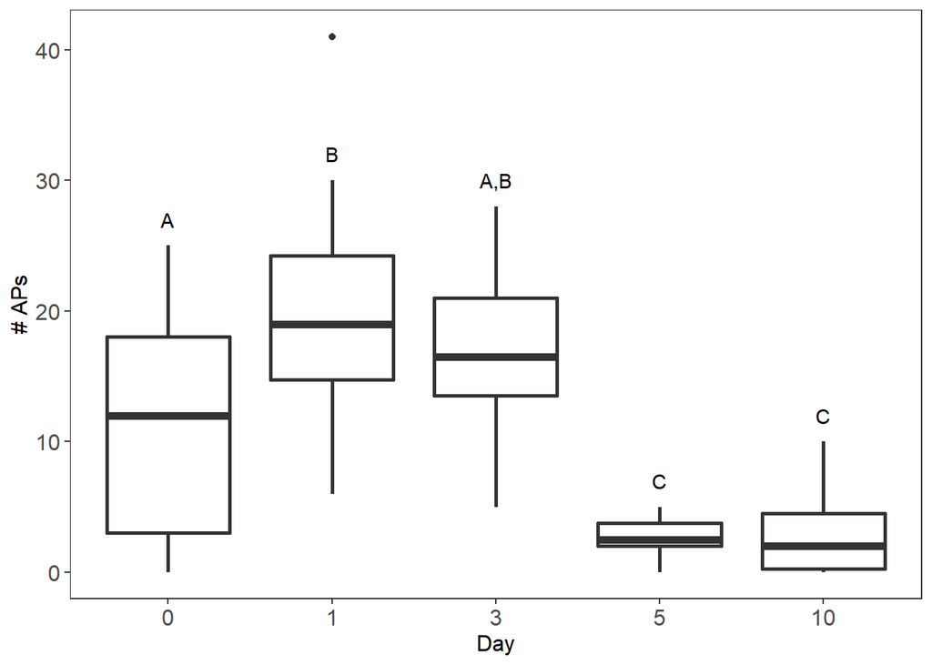

```r
## First we have to get the days back in the right order

totalsums$sampleday <- factor(totalsums$sampleday,
                              levels = c("0","1","3","5", "10"))

## Now plot

ggplot(totalsums, aes(x=sampleday , y=sum)) +
  geom_boxplot(position=position_dodge(), size=1) +
  xlab('Day') +
  coord_cartesian(ylim = c(0, 41)) +
  ylab('# APs') +
  guides(fill=FALSE) +
  theme_bw() +
  theme(text = element_text(size=12),
        axis.text.x = element_text(size = 12),
        axis.text.y = element_text(size = 12),
        strip.background = element_blank(),
        panel.grid.major = element_blank(),
        panel.grid.minor = element_blank()) +
  annotate("text", x=1, y=27, label = "A") +
  annotate("text", x=2, y=32, label = "B") +
  annotate("text", x=3, y=30, label = "A,B") +
  annotate("text", x=4, y=7, label = "C") +
  annotate("text", x=5, y=12, label = "C")
```